# Stroke Prediction

### Decision tree

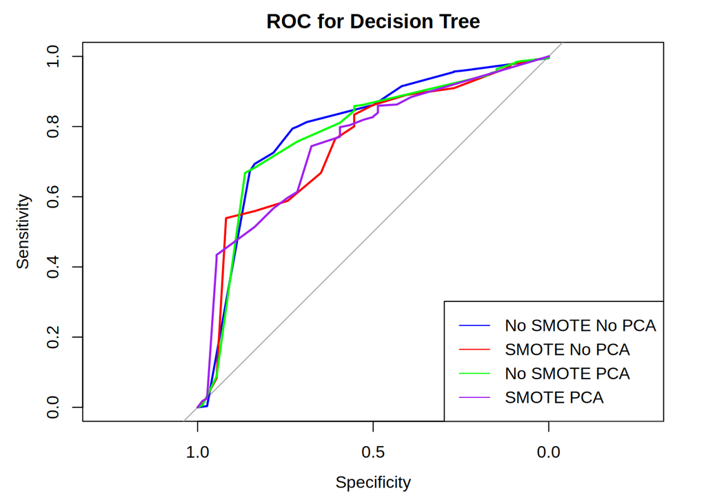

```r
#Decision Tree
# No SMOTE, No PCA
set.seed(123)
dt_no_smote_no_pca = train(
  stroke ~ .,
  data = train_data,
  method = "rpart",
  trControl = ctrl_base,
  tuneLength = 5,  # Tune complexity parameter
  metric = "ROC"
)
dt_pred_no_smote_no_pca_prob = predict(dt_no_smote_no_pca, newdata = test_data, type = "prob")
dt_pred_no_smote_no_pca_class = predict(dt_no_smote_no_pca, newdata = test_data, type = "raw")
roc_dt_no_smote_no_pca = roc(test_data$stroke, dt_pred_no_smote_no_pca_prob[,"YES"])
acc_dt_no_smote_no_pca = confusionMatrix(dt_pred_no_smote_no_pca_class, test_data$stroke)$overall["Accuracy"]


# SMOTE, No PCA
set.seed(123)
dt_smote_no_pca = train(
  stroke ~ .,
  data = train_data,
  method = "rpart",
  trControl = ctrl_smote,
  tuneLength = 5,
  metric = "ROC"
)
dt_pred_smote_no_pca_prob = predict(dt_smote_no_pca, newdata = test_data, type = "prob")
dt_pred_smote_no_pca_class = predict(dt_smote_no_pca, newdata = test_data, type = "raw")
roc_dt_smote_no_pca = roc(test_data$stroke, dt_pred_smote_no_pca_prob[,"YES"])
acc_dt_smote_no_pca = confusionMatrix(dt_pred_smote_no_pca_class, test_data$stroke)$overall["Accuracy"]


# No SMOTE, PCA
set.seed(123)
dt_no_smote_pca = train(
  stroke ~ .,
  data = train_data,
  method = "rpart",
  trControl = ctrl_base,
  preProcess = c("center", "scale", "pca"),
  tuneLength = 5,
  metric = "ROC"
)
dt_pred_no_smote_pca_prob = predict(dt_no_smote_pca, newdata = test_data, type = "prob")
dt_pred_no_smote_pca_class = predict(dt_no_smote_pca, newdata = test_data, type = "raw")
roc_dt_no_smote_pca = roc(test_data$stroke, dt_pred_no_smote_pca_prob[,"YES"])
acc_dt_no_smote_pca = confusionMatrix(dt_pred_no_smote_pca_class, test_data$stroke)$overall["Accuracy"]


# SMOTE, PCA
set.seed(123)
dt_smote_pca = train(
  stroke ~ .,
  data = train_data,
  method = "rpart",
  trControl = ctrl_smote,
  preProcess = c("center", "scale", "pca"),
  tuneLength = 5,
  metric = "ROC"
)
dt_pred_smote_pca_prob = predict(dt_smote_pca, newdata = test_data, type = "prob")
dt_pred_smote_pca_class = predict(dt_smote_pca, newdata = test_data, type = "raw")
roc_dt_smote_pca = roc(test_data$stroke, dt_pred_smote_pca_prob[,"YES"])
acc_dt_smote_pca = confusionMatrix(dt_pred_smote_pca_class, test_data$stroke)$overall["Accuracy"]


# Plot ROC curves
plot(roc_dt_no_smote_no_pca, col = "blue", main = "ROC for Decision Tree")
lines(roc_dt_smote_no_pca, col = "red")
lines(roc_dt_no_smote_pca, col = "green")
lines(roc_dt_smote_pca, col = "purple")
legend("bottomright",
       legend = c("No SMOTE No PCA", "SMOTE No PCA", "No SMOTE PCA", "SMOTE PCA"),
       col = c("blue", "red", "green", "purple"),
       lty = 1)
```

### Random forest

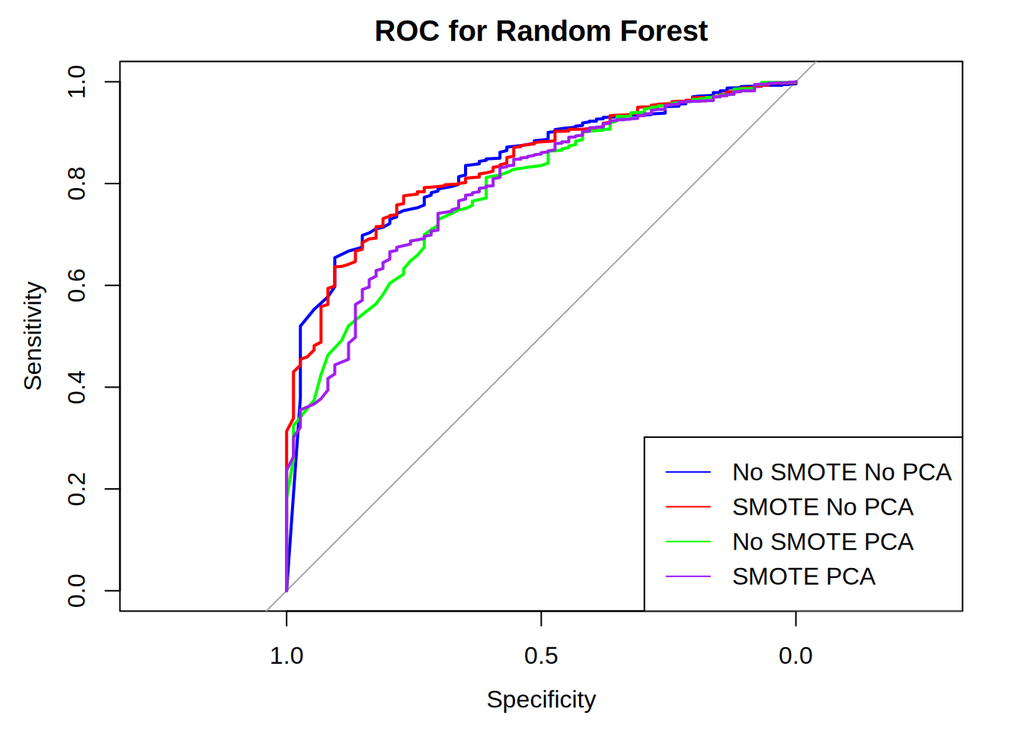

```r
#Random Forest
# No SMOTE, No PCA
set.seed(123)
rf_no_smote_no_pca = train(
  stroke ~ .,
  data = train_data,
  method = "rf",
  trControl = ctrl_base,
  tuneLength = 3,  # Tune mtry
  metric = "ROC"
)
rf_pred_no_smote_no_pca = predict(rf_no_smote_no_pca, newdata = test_data, type = "prob")
roc_rf_no_smote_no_pca = roc(test_data$stroke, rf_pred_no_smote_no_pca[,"YES"])
rf_pred_no_smote_no_pca_class = predict(rf_no_smote_no_pca, newdata = test_data, type = "raw")
acc_rf_no_smote_no_pca = confusionMatrix(rf_pred_no_smote_no_pca_class, test_data$stroke)$overall["Accuracy"]

# SMOTE, No PCA
set.seed(123)
rf_smote_no_pca = train(
  stroke ~ .,
  data = train_data,
  method = "rf",
  trControl = ctrl_smote,
  tuneLength = 3,
  metric = "ROC"
)
rf_pred_smote_no_pca = predict(rf_smote_no_pca, newdata = test_data, type = "prob")
roc_rf_smote_no_pca = roc(test_data$stroke, rf_pred_smote_no_pca[,"YES"])
rf_pred_smote_no_pca_class = predict(rf_smote_no_pca, newdata = test_data, type = "raw")
acc_rf_smote_no_pca = confusionMatrix(rf_pred_smote_no_pca_class, test_data$stroke)$overall["Accuracy"]

# No SMOTE, PCA
set.seed(123)
rf_no_smote_pca = train(
  stroke ~ .,
  data = train_data,
  method = "rf",
  trControl = ctrl_base,
  preProcess = c("center", "scale", "pca"),
  tuneLength = 3,
  metric = "ROC"
)
rf_pred_no_smote_pca = predict(rf_no_smote_pca, newdata = test_data, type = "prob")
roc_rf_no_smote_pca = roc(test_data$stroke, rf_pred_no_smote_pca[,"YES"])
rf_pred_no_smote_pca_class = predict(rf_no_smote_pca, newdata = test_data, type = "raw")
acc_rf_no_smote_pca = confusionMatrix(rf_pred_no_smote_pca_class, test_data$stroke)$overall["Accuracy"]

# SMOTE, PCA
set.seed(123)
rf_smote_pca = train(
  stroke ~ .,
  data = train_data,
  method = "rf",
  trControl = ctrl_smote,
  preProcess = c("center", "scale", "pca"),
  tuneLength = 3,
  metric = "ROC"
)
rf_pred_smote_pca = predict(rf_smote_pca, newdata = test_data, type = "prob")
roc_rf_smote_pca = roc(test_data$stroke, rf_pred_smote_pca[,"YES"])
rf_pred_smote_pca_class = predict(rf_smote_pca, newdata = test_data, type = "raw")
acc_rf_smote_pca = confusionMatrix(rf_pred_smote_pca_class, test_data$stroke)$overall["Accuracy"]

# Plot ROC curves
plot(roc_rf_no_smote_no_pca, col = "blue", main = "ROC for Random Forest")
lines(roc_rf_smote_no_pca, col = "red")
lines(roc_rf_no_smote_pca, col = "green")
lines(roc_rf_smote_pca, col = "purple")
legend("bottomright",
       legend = c("No SMOTE No PCA", "SMOTE No PCA", "No SMOTE PCA", "SMOTE PCA"),
       col = c("blue", "red", "green", "purple"),
       lty = 1)
```

### Bagging

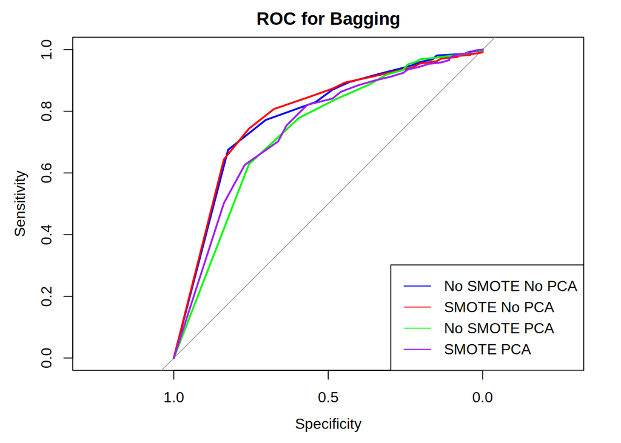

```r
#Bagging
# No SMOTE, No PCA
set.seed(123)
bag_no_smote_no_pca = train(
  stroke ~ .,
  data = train_data,
  method = "treebag",
  trControl = ctrl_base,
  metric = "ROC"
)
bag_pred_no_smote_no_pca = predict(bag_no_smote_no_pca, newdata = test_data, type = "prob")
roc_bag_no_smote_no_pca = roc(test_data$stroke, bag_pred_no_smote_no_pca[,"YES"])
bag_pred_no_smote_no_pca_class = predict(bag_no_smote_no_pca, newdata = test_data, type = "raw")
acc_bag_no_smote_no_pca = confusionMatrix(bag_pred_no_smote_no_pca_class, test_data$stroke)$overall["Accuracy"]

# SMOTE, No PCA
set.seed(123)
bag_smote_no_pca = train(
  stroke ~ .,
  data = train_data,
  method = "treebag",
  trControl = ctrl_smote,
  metric = "ROC"
)
bag_pred_smote_no_pca = predict(bag_smote_no_pca, newdata = test_data, type = "prob")
roc_bag_smote_no_pca = roc(test_data$stroke, bag_pred_smote_no_pca[,"YES"])
bag_pred_smote_no_pca_class = predict(bag_smote_no_pca, newdata = test_data, type = "raw")
acc_bag_smote_no_pca = confusionMatrix(bag_pred_smote_no_pca_class, test_data$stroke)$overall["Accuracy"]

# No SMOTE, PCA
set.seed(123)
bag_no_smote_pca = train(
  stroke ~ .,
  data = train_data,
  method = "treebag",
  trControl = ctrl_base,
  preProcess = c("center", "scale", "pca"),
  metric = "ROC"
)
bag_pred_no_smote_pca = predict(bag_no_smote_pca, newdata = test_data, type = "prob")
roc_bag_no_smote_pca = roc(test_data$stroke, bag_pred_no_smote_pca[,"YES"])
bag_pred_no_smote_pca_class = predict(bag_no_smote_pca, newdata = test_data, type = "raw")
acc_bag_no_smote_pca = confusionMatrix(bag_pred_no_smote_pca_class, test_data$stroke)$overall["Accuracy"]

# SMOTE, PCA
set.seed(123)
bag_smote_pca = train(
  stroke ~ .,
  data = train_data,
  method = "treebag",
  trControl = ctrl_smote,
  preProcess = c("center", "scale", "pca"),
  metric = "ROC"
)
bag_pred_smote_pca = predict(bag_smote_pca, newdata = test_data, type = "prob")
roc_bag_smote_pca = roc(test_data$stroke, bag_pred_smote_pca[,"YES"])
bag_pred_smote_pca_class = predict(bag_smote_pca, newdata = test_data, type = "raw")
acc_bag_smote_pca = confusionMatrix(bag_pred_smote_pca_class, test_data$stroke)$overall["Accuracy"]

# Plot ROC curves
plot(roc_bag_no_smote_no_pca, col = "blue", main = "ROC for Bagging")
lines(roc_bag_smote_no_pca, col = "red")
lines(roc_bag_no_smote_pca, col = "green")
lines(roc_bag_smote_pca, col = "purple")
legend("bottomright",
       legend = c("No SMOTE No PCA", "SMOTE No PCA", "No SMOTE PCA", "SMOTE PCA"),
       col = c("blue", "red", "green", "purple"),
       lty = 1)
```

### Boosting

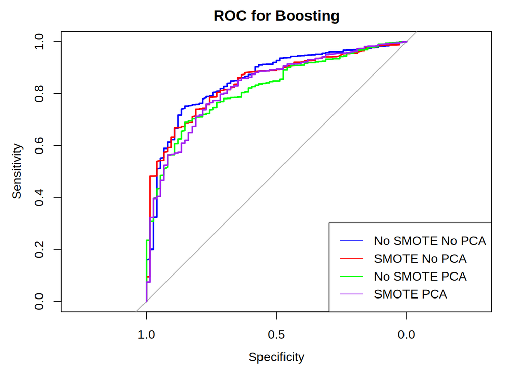

```r
#Boosting
# No SMOTE, No PCA
set.seed(123)
boost_no_smote_no_pca = train(
  stroke ~ .,
  data = train_data,
  method = "gbm",
  trControl = ctrl_base,
  tuneLength = 3,  # Tune n.trees, interaction.depth, etc.
  metric = "ROC",
  verbose = FALSE
)
boost_pred_no_smote_no_pca = predict(boost_no_smote_no_pca, newdata = test_data, type = "prob")
roc_boost_no_smote_no_pca = roc(test_data$stroke, boost_pred_no_smote_no_pca[,"YES"])
boost_pred_no_smote_no_pca_class = predict(boost_no_smote_no_pca, newdata = test_data, type = "raw")
acc_boost_no_smote_no_pca = confusionMatrix(boost_pred_no_smote_no_pca_class, test_data$stroke)$overall["Accuracy"]

# SMOTE, No PCA
set.seed(123)
boost_smote_no_pca = train(
  stroke ~ .,
  data = train_data,
  method = "gbm",
  trControl = ctrl_smote,
  tuneLength = 3,
  metric = "ROC",
  verbose = FALSE
)
boost_pred_smote_no_pca = predict(boost_smote_no_pca, newdata = test_data, type = "prob")
roc_boost_smote_no_pca = roc(test_data$stroke, boost_pred_smote_no_pca[,"YES"])
boost_pred_smote_no_pca_class = predict(boost_smote_no_pca, newdata = test_data, type = "raw")
acc_boost_smote_no_pca = confusionMatrix(boost_pred_smote_no_pca_class, test_data$stroke)$overall["Accuracy"]

# No SMOTE, PCA
set.seed(123)
boost_no_smote_pca = train(
  stroke ~ .,
  data = train_data,
  method = "gbm",
  trControl = ctrl_base,
  preProcess = c("center", "scale", "pca"),
  tuneLength = 3,
  metric = "ROC",
  verbose = FALSE
)
boost_pred_no_smote_pca = predict(boost_no_smote_pca, newdata = test_data, type = "prob")
roc_boost_no_smote_pca = roc(test_data$stroke, boost_pred_no_smote_pca[,"YES"])
boost_pred_no_smote_pca_class = predict(boost_no_smote_pca, newdata = test_data, type = "raw")
acc_boost_no_smote_pca = confusionMatrix(boost_pred_no_smote_pca_class, test_data$stroke)$overall["Accuracy"]

# SMOTE, PCA
set.seed(123)
boost_smote_pca = train(
  stroke ~ .,
  data = train_data,
  method = "gbm",
  trControl = ctrl_smote,
  preProcess = c("center", "scale", "pca"),
  tuneLength = 3,
  metric = "ROC",
  verbose = FALSE
)
boost_pred_smote_pca = predict(boost_smote_pca, newdata = test_data, type = "prob")
roc_boost_smote_pca = roc(test_data$stroke, boost_pred_smote_pca[,"YES"])
boost_pred_smote_pca_class = predict(boost_smote_pca, newdata = test_data, type = "raw")
acc_boost_smote_pca = confusionMatrix(boost_pred_smote_pca_class, test_data$stroke)$overall["Accuracy"]

# Plot ROC curves
plot(roc_boost_no_smote_no_pca, col = "blue", main = "ROC for Boosting")
lines(roc_boost_smote_no_pca, col = "red")
lines(roc_boost_no_smote_pca, col = "green")
lines(roc_boost_smote_pca, col = "purple")
legend("bottomright",
       legend = c("No SMOTE No PCA", "SMOTE No PCA", "No SMOTE PCA", "SMOTE PCA"),
       col = c("blue", "red", "green", "purple"),
       lty = 1)
```

# Results

Every model-scenario pair is scored on the test set: AUC from the ROC curve, plus accuracy, sensitivity, and specificity from the confusion matrix. The table collects all four metrics; the bar plots after it make the trade-offs visual. QDA rows with failed fits are dropped.

```r
sens_logit_no_smote_no_pca = confusionMatrix(logit_pred_no_smote_no_pca_class, test_data$stroke)$byClass["Sensitivity"]
sens_logit_smote_no_pca = confusionMatrix(logit_pred_smote_no_pca_class, test_data$stroke)$byClass["Sensitivity"]
sens_logit_no_smote_pca = confusionMatrix(logit_pred_no_smote_pca_class, test_data$stroke)$byClass["Sensitivity"]
sens_logit_smote_pca = confusionMatrix(logit_pred_smote_pca_class, test_data$stroke)$byClass["Sensitivity"]
sens_lda_no_smote_no_pca = confusionMatrix(lda_pred_no_smote_no_pca_class, test_data$stroke)$byClass["Sensitivity"]
sens_lda_smote_no_pca = confusionMatrix(lda_pred_smote_no_pca_class, test_data$stroke)$byClass["Sensitivity"]
sens_lda_no_smote_pca = confusionMatrix(lda_pred_no_smote_pca_class, test_data$stroke)$byClass["Sensitivity"]
sens_lda_smote_pca = confusionMatrix(lda_pred_smote_pca_class, test_data$stroke)$byClass["Sensitivity"]
sens_qda_no_smote_no_pca = if (!is.null(qda_pred_no_smote_no_pca_class)) {
  confusionMatrix(qda_pred_no_smote_no_pca_class, test_data$stroke)$byClass["Sensitivity"]
} else {
  NA
}
sens_qda_smote_no_pca = if (!is.null(qda_pred_smote_no_pca_class)) {
  confusionMatrix(qda_pred_smote_no_pca_class, test_data$stroke)$byClass["Sensitivity"]
} else {
  NA
}
sens_qda_no_smote_pca = confusionMatrix(qda_pred_no_smote_pca_class, test_data$stroke)$byClass["Sensitivity"]
sens_qda_smote_pca = confusionMatrix(qda_pred_smote_pca_class, test_data$stroke)$byClass["Sensitivity"]
sens_dt_no_smote_no_pca = confusionMatrix(dt_pred_no_smote_no_pca_class, test_data$stroke)$byClass["Sensitivity"]
sens_dt_smote_no_pca = confusionMatrix(dt_pred_smote_no_pca_class, test_data$stroke)$byClass["Sensitivity"]
sens_dt_no_smote_pca = confusionMatrix(dt_pred_no_smote_pca_class, test_data$stroke)$byClass["Sensitivity"]
sens_dt_smote_pca = confusionMatrix(dt_pred_smote_pca_class, test_data$stroke)$byClass["Sensitivity"]
sens_rf_no_smote_no_pca = confusionMatrix(rf_pred_no_smote_no_pca_class, test_data$stroke)$byClass["Sensitivity"]
sens_rf_smote_no_pca = confusionMatrix(rf_pred_smote_no_pca_class, test_data$stroke)$byClass["Sensitivity"]
sens_rf_no_smote_pca = confusionMatrix(rf_pred_no_smote_pca_class, test_data$stroke)$byClass["Sensitivity"]
sens_rf_smote_pca = confusionMatrix(rf_pred_smote_pca_class, test_data$stroke)$byClass["Sensitivity"]
sens_bag_no_smote_no_pca = confusionMatrix(bag_pred_no_smote_no_pca_class, test_data$stroke)$byClass["Sensitivity"]
sens_bag_smote_no_pca = confusionMatrix(bag_pred_smote_no_pca_class, test_data$stroke)$byClass["Sensitivity"]
sens_bag_no_smote_pca = confusionMatrix(bag_pred_no_smote_pca_class, test_data$stroke)$byClass["Sensitivity"]
sens_bag_smote_pca = confusionMatrix(bag_pred_smote_pca_class, test_data$stroke)$byClass["Sensitivity"]
sens_boost_no_smote_no_pca = confusionMatrix(boost_pred_no_smote_no_pca_class, test_data$stroke)$byClass["Sensitivity"]
sens_boost_smote_no_pca = confusionMatrix(boost_pred_smote_no_pca_class, test_data$stroke)$byClass["Sensitivity"]
sens_boost_no_smote_pca = confusionMatrix(boost_pred_no_smote_pca_class, test_data$stroke)$byClass["Sensitivity"]
sens_boost_smote_pca = confusionMatrix(boost_pred_smote_pca_class, test_data$stroke)$byClass["Sensitivity"]
sens_knn_no_smote_no_pca = confusionMatrix(knn_pred_no_smote_no_pca_class, test_data$stroke)$byClass["Sensitivity"]
sens_knn_smote_no_pca = confusionMatrix(knn_pred_smote_no_pca_class, test_data$stroke)$byClass["Sensitivity"]
sens_knn_no_smote_pca = confusionMatrix(knn_pred_no_smote_pca_class, test_data$stroke)$byClass["Sensitivity"]
sens_knn_smote_pca = confusionMatrix(knn_pred_smote_pca_class, test_data$stroke)$byClass["Sensitivity"]
```

```r
spec_logit_no_smote_no_pca = confusionMatrix(logit_pred_no_smote_no_pca_class, test_data$stroke)$byClass["Specificity"]
spec_logit_smote_no_pca = confusionMatrix(logit_pred_smote_no_pca_class, test_data$stroke)$byClass["Specificity"]
spec_logit_no_smote_pca = confusionMatrix(logit_pred_no_smote_pca_class, test_data$stroke)$byClass["Specificity"]
spec_logit_smote_pca = confusionMatrix(logit_pred_smote_pca_class, test_data$stroke)$byClass["Specificity"]
spec_lda_no_smote_no_pca = confusionMatrix(lda_pred_no_smote_no_pca_class, test_data$stroke)$byClass["Specificity"]
spec_lda_smote_no_pca = confusionMatrix(lda_pred_smote_no_pca_class, test_data$stroke)$byClass["Specificity"]
spec_lda_no_smote_pca = confusionMatrix(lda_pred_no_smote_pca_class, test_data$stroke)$byClass["Specificity"]
spec_lda_smote_pca = confusionMatrix(lda_pred_smote_pca_class, test_data$stroke)$byClass["Specificity"]
spec_qda_no_smote_no_pca = if (!is.null(qda_pred_no_smote_no_pca_class)) {
  confusionMatrix(qda_pred_no_smote_no_pca_class, test_data$stroke)$byClass["Specificity"]
} else {
  NA
}
spec_qda_smote_no_pca = if (!is.null(qda_pred_smote_no_pca_class)) {
  confusionMatrix(qda_pred_smote_no_pca_class, test_data$stroke)$byClass["Specificity"]
} else {
  NA
}
spec_qda_no_smote_pca = confusionMatrix(qda_pred_no_smote_pca_class, test_data$stroke)$byClass["Specificity"]
spec_qda_smote_pca = confusionMatrix(qda_pred_smote_pca_class, test_data$stroke)$byClass["Specificity"]
spec_dt_no_smote_no_pca = confusionMatrix(dt_pred_no_smote_no_pca_class, test_data$stroke)$byClass["Specificity"]
spec_dt_smote_no_pca = confusionMatrix(dt_pred_smote_no_pca_class, test_data$stroke)$byClass["Specificity"]
spec_dt_no_smote_pca = confusionMatrix(dt_pred_no_smote_pca_class, test_data$stroke)$byClass["Specificity"]
spec_dt_smote_pca = confusionMatrix(dt_pred_smote_pca_class, test_data$stroke)$byClass["Specificity"]
spec_rf_no_smote_no_pca = confusionMatrix(rf_pred_no_smote_no_pca_class, test_data$stroke)$byClass["Specificity"]
spec_rf_smote_no_pca = confusionMatrix(rf_pred_smote_no_pca_class, test_data$stroke)$byClass["Specificity"]
spec_rf_no_smote_pca = confusionMatrix(rf_pred_no_smote_pca_class, test_data$stroke)$byClass["Specificity"]
spec_rf_smote_pca = confusionMatrix(rf_pred_smote_pca_class, test_data$stroke)$byClass["Specificity"]
spec_bag_no_smote_no_pca = confusionMatrix(bag_pred_no_smote_no_pca_class, test_data$stroke)$byClass["Specificity"]
spec_bag_smote_no_pca = confusionMatrix(bag_pred_smote_no_pca_class, test_data$stroke)$byClass["Specificity"]
spec_bag_no_smote_pca = confusionMatrix(bag_pred_no_smote_pca_class, test_data$stroke)$byClass["Specificity"]
spec_bag_smote_pca = confusionMatrix(bag_pred_smote_pca_class, test_data$stroke)$byClass["Specificity"]
spec_boost_no_smote_no_pca = confusionMatrix(boost_pred_no_smote_no_pca_class, test_data$stroke)$byClass["Specificity"]
spec_boost_smote_no_pca = confusionMatrix(boost_pred_smote_no_pca_class, test_data$stroke)$byClass["Specificity"]
spec_boost_no_smote_pca = confusionMatrix(boost_pred_no_smote_pca_class, test_data$stroke)$byClass["Specificity"]
spec_boost_smote_pca = confusionMatrix(boost_pred_smote_pca_class, test_data$stroke)$byClass["Specificity"]
spec_knn_no_smote_no_pca = confusionMatrix(knn_pred_no_smote_no_pca_class, test_data$stroke)$byClass["Specificity"]
spec_knn_smote_no_pca = confusionMatrix(knn_pred_smote_no_pca_class, test_data$stroke)$byClass["Specificity"]
spec_knn_no_smote_pca = confusionMatrix(knn_pred_no_smote_pca_class, test_data$stroke)$byClass["Specificity"]
spec_knn_smote_pca = confusionMatrix(knn_pred_smote_pca_class, test_data$stroke)$byClass["Specificity"]
```

```r
results_df = data.frame(
  Model = rep(c("Logistic Regression", "LDA", "QDA", "Decision Tree",
                "Random Forest", "Bagging", "Boosting", "KNN"), each = 4),
  Scenario = rep(c("No SMOTE No PCA", "SMOTE No PCA", "No SMOTE PCA", "SMOTE PCA"), 8),
  AUC = c(
    auc(roc_logit_no_smote_no_pca), auc(roc_logit_smote_no_pca), auc(roc_logit_no_smote_pca), auc(roc_logit_smote_pca),
    auc(roc_lda_no_smote_no_pca), auc(roc_lda_smote_no_pca), auc(roc_lda_no_smote_pca), auc(roc_lda_smote_pca),
    if (!is.null(roc_qda_no_smote_no_pca)) auc(roc_qda_no_smote_no_pca) else NA,
    if (!is.null(roc_qda_smote_no_pca)) auc(roc_qda_smote_no_pca) else NA,
    auc(roc_qda_no_smote_pca), auc(roc_qda_smote_pca),
    auc(roc_dt_no_smote_no_pca), auc(roc_dt_smote_no_pca), auc(roc_dt_no_smote_pca), auc(roc_dt_smote_pca),
    auc(roc_rf_no_smote_no_pca), auc(roc_rf_smote_no_pca), auc(roc_rf_no_smote_pca), auc(roc_rf_smote_pca),
    auc(roc_bag_no_smote_no_pca), auc(roc_bag_smote_no_pca), auc(roc_bag_no_smote_pca), auc(roc_bag_smote_pca),
    auc(roc_boost_no_smote_no_pca), auc(roc_boost_smote_no_pca), auc(roc_boost_no_smote_pca), auc(roc_boost_smote_pca),
    auc(roc_knn_no_smote_no_pca), auc(roc_knn_smote_no_pca), auc(roc_knn_no_smote_pca), auc(roc_knn_smote_pca)
  ),
  Accuracy = c(
    acc_logit_no_smote_no_pca, acc_logit_smote_no_pca, acc_logit_no_smote_pca, acc_logit_smote_pca,
    acc_lda_no_smote_no_pca, acc_lda_smote_no_pca, acc_lda_no_smote_pca, acc_lda_smote_pca,
    acc_qda_no_smote_no_pca, acc_qda_smote_no_pca, acc_qda_no_smote_pca, acc_qda_smote_pca,
    acc_dt_no_smote_no_pca, acc_dt_smote_no_pca, acc_dt_no_smote_pca, acc_dt_smote_pca,
    acc_rf_no_smote_no_pca, acc_rf_smote_no_pca, acc_rf_no_smote_pca, acc_rf_smote_pca,
    acc_bag_no_smote_no_pca, acc_bag_smote_no_pca, acc_bag_no_smote_pca, acc_bag_smote_pca,
    acc_boost_no_smote_no_pca, acc_boost_smote_no_pca, acc_boost_no_smote_pca, acc_boost_smote_pca,
    acc_knn_no_smote_no_pca, acc_knn_smote_no_pca, acc_knn_no_smote_pca, acc_knn_smote_pca
  ),
  Sensitivity = c(
    sens_logit_no_smote_no_pca, sens_logit_smote_no_pca, sens_logit_no_smote_pca, sens_logit_smote_pca,
    sens_lda_no_smote_no_pca, sens_lda_smote_no_pca, sens_lda_no_smote_pca, sens_lda_smote_pca,
    sens_qda_no_smote_no_pca, sens_qda_smote_no_pca, sens_qda_no_smote_pca, sens_qda_smote_pca,
    sens_dt_no_smote_no_pca, sens_dt_smote_no_pca, sens_dt_no_smote_pca, sens_dt_smote_pca,
    sens_rf_no_smote_no_pca, sens_rf_smote_no_pca, sens_rf_no_smote_pca, sens_rf_smote_pca,
    sens_bag_no_smote_no_pca, sens_bag_smote_no_pca, sens_bag_no_smote_pca, sens_bag_smote_pca,
    sens_boost_no_smote_no_pca, sens_boost_smote_no_pca, sens_boost_no_smote_pca, sens_boost_smote_pca,
    sens_knn_no_smote_no_pca, sens_knn_smote_no_pca, sens_knn_no_smote_pca, sens_knn_smote_pca
  ),
  Specificity = c(
    spec_logit_no_smote_no_pca, spec_logit_smote_no_pca, spec_logit_no_smote_pca, spec_logit_smote_pca,
    spec_lda_no_smote_no_pca, spec_lda_smote_no_pca, spec_lda_no_smote_pca, spec_lda_smote_pca,
    spec_qda_no_smote_no_pca, spec_qda_smote_no_pca, spec_qda_no_smote_pca, spec_qda_smote_pca,
    spec_dt_no_smote_no_pca, spec_dt_smote_no_pca, spec_dt_no_smote_pca, spec_dt_smote_pca,
    spec_rf_no_smote_no_pca, spec_rf_smote_no_pca, spec_rf_no_smote_pca, spec_rf_smote_pca,
    spec_bag_no_smote_no_pca, spec_bag_smote_no_pca, spec_bag_no_smote_pca, spec_bag_smote_pca,
    spec_boost_no_smote_no_pca, spec_boost_smote_no_pca, spec_boost_no_smote_pca, spec_boost_smote_pca,
    spec_knn_no_smote_no_pca, spec_knn_smote_no_pca, spec_knn_no_smote_pca, spec_knn_smote_pca
  )
) %>%
  filter(!is.na(AUC) & !is.na(Accuracy) & !is.na(Specificity))

kable(results_df, caption = "AUC, Accuracy,Sensitivity, and Specificity for Each Model and Scenario (NA Removed)", digits = 4)
```

AUC, Accuracy,Sensitivity, and Specificity for Each Model and Scenario (NA Removed)

| Model | Scenario | AUC | Accuracy | Sensitivity | Specificity |
| --- | --- | --- | --- | --- | --- |
| Logistic Regression | No SMOTE No PCA | 0.8570 | 0.9517 | 0.0000 | 1.0000 |
| Logistic Regression | SMOTE No PCA | 0.8554 | 0.7487 | 0.7973 | 0.7462 |
| Logistic Regression | No SMOTE PCA | 0.8418 | 0.9517 | 0.0000 | 1.0000 |
| Logistic Regression | SMOTE PCA | 0.8498 | 0.7441 | 0.7973 | 0.7414 |
| LDA | No SMOTE No PCA | 0.8505 | 0.9478 | 0.0405 | 0.9938 |
| LDA | SMOTE No PCA | 0.8564 | 0.7324 | 0.8108 | 0.7284 |
| LDA | No SMOTE PCA | 0.8351 | 0.9439 | 0.0405 | 0.9897 |
| LDA | SMOTE PCA | 0.8453 | 0.7304 | 0.8108 | 0.7263 |
| QDA | No SMOTE PCA | 0.8182 | 0.6345 | 0.8243 | 0.6248 |
| QDA | SMOTE PCA | 0.8262 | 0.4869 | 0.9730 | 0.4623 |
| Decision Tree | No SMOTE No PCA | 0.7951 | 0.9399 | 0.0541 | 0.9849 |
| Decision Tree | SMOTE No PCA | 0.7494 | 0.8668 | 0.4054 | 0.8903 |
| Decision Tree | No SMOTE PCA | 0.7801 | 0.9426 | 0.0811 | 0.9863 |
| Decision Tree | SMOTE PCA | 0.7551 | 0.8055 | 0.5270 | 0.8196 |
| Random Forest | No SMOTE No PCA | 0.8357 | 0.9491 | 0.0000 | 0.9973 |
| Random Forest | SMOTE No PCA | 0.8358 | 0.9315 | 0.1892 | 0.9691 |
| Random Forest | No SMOTE PCA | 0.7878 | 0.9517 | 0.0676 | 0.9966 |
| Random Forest | SMOTE PCA | 0.7932 | 0.9243 | 0.2162 | 0.9602 |
| Bagging | No SMOTE No PCA | 0.7823 | 0.9439 | 0.0541 | 0.9890 |
| Bagging | SMOTE No PCA | 0.7872 | 0.9328 | 0.0811 | 0.9760 |
| Bagging | No SMOTE PCA | 0.7317 | 0.9432 | 0.0541 | 0.9883 |
| Bagging | SMOTE PCA | 0.7434 | 0.9014 | 0.2432 | 0.9348 |
| Boosting | No SMOTE No PCA | 0.8532 | 0.9517 | 0.0000 | 1.0000 |
| Boosting | SMOTE No PCA | 0.8430 | 0.9073 | 0.3514 | 0.9355 |
| Boosting | No SMOTE PCA | 0.8183 | 0.9458 | 0.0811 | 0.9897 |
| Boosting | SMOTE PCA | 0.8280 | 0.7520 | 0.7703 | 0.7510 |
| KNN | No SMOTE No PCA | 0.7440 | 0.9517 | 0.0135 | 0.9993 |
| KNN | SMOTE No PCA | 0.7734 | 0.7931 | 0.6216 | 0.8018 |
| KNN | No SMOTE PCA | 0.6828 | 0.9504 | 0.0000 | 0.9986 |
| KNN | SMOTE PCA | 0.7188 | 0.8531 | 0.3649 | 0.8779 |

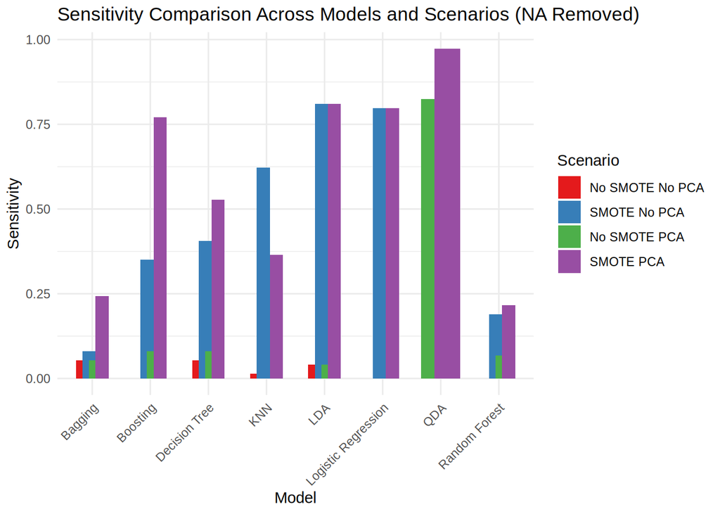

```r
results_df$Scenario = factor(results_df$Scenario,
                             levels = c("No SMOTE No PCA", "SMOTE No PCA",
                                        "No SMOTE PCA", "SMOTE PCA"))

ggplot(results_df, aes(x = Model, y = Sensitivity, fill = Scenario)) +
  geom_bar(stat = "identity", position = position_dodge(width = 0.45)) +
  labs(title = "Sensitivity Comparison Across Models and Scenarios (NA Removed)",
       x = "Model",
       y = "Sensitivity") +
  theme_minimal() +
  theme(axis.text.x = element_text(angle = 45, hjust = 1)) +
  scale_fill_brewer(palette = "Set1")
```

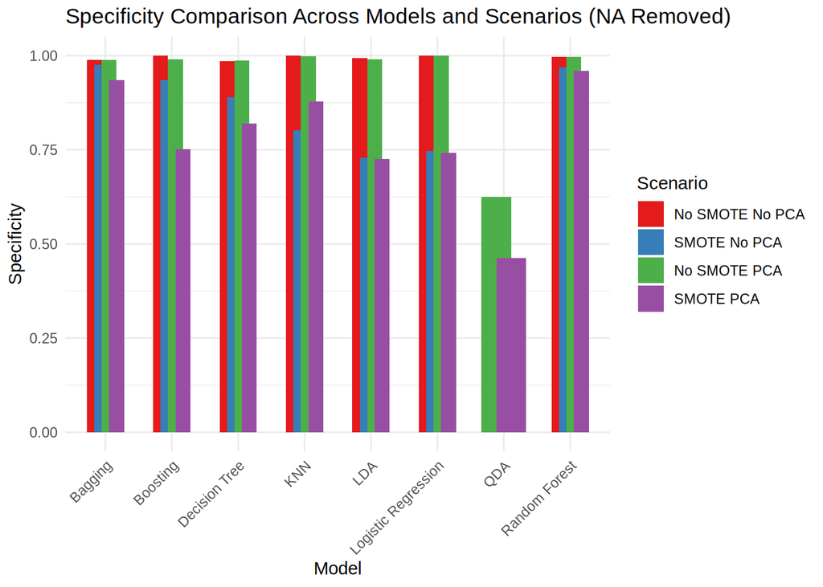

```r
results_df$Scenario = factor(results_df$Scenario,
                             levels = c("No SMOTE No PCA", "SMOTE No PCA",
                                        "No SMOTE PCA", "SMOTE PCA"))

ggplot(results_df, aes(x = Model, y = Specificity, fill = Scenario)) +
  geom_bar(stat = "identity", position = position_dodge(width = 0.45)) +
  labs(title = "Specificity Comparison Across Models and Scenarios (NA Removed)",
       x = "Model",
       y = "Specificity") +
  theme_minimal() +
  theme(axis.text.x = element_text(angle = 45, hjust = 1)) +
  scale_fill_brewer(palette = "Set1")
```

Because the QDA model fails to fit in every fold due to the rank deficiency issue, no predictions are produced. Without predictions, the performance metrics (like ROC) cannot be computed, leading to the “missing values” warning.

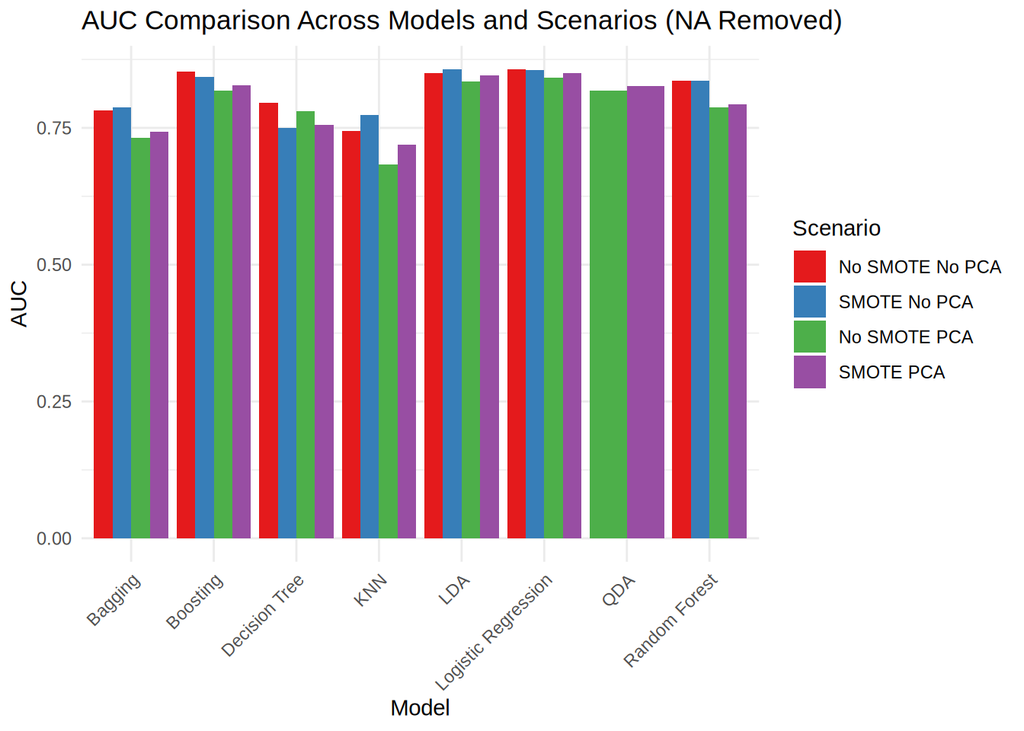

```r
# Convert Scenario to factor for consistent ordering
results_df$Scenario = factor(results_df$Scenario,
                         levels = c("No SMOTE No PCA", "SMOTE No PCA",
                                    "No SMOTE PCA", "SMOTE PCA"))

# Create grouped bar plot
ggplot(results_df, aes(x = Model, y = AUC, fill = Scenario)) +
  geom_bar(stat = "identity", position = position_dodge(width = 0.9)) +
  labs(title = "AUC Comparison Across Models and Scenarios (NA Removed)",
       x = "Model",
       y = "AUC") +
  theme_minimal() +
  theme(axis.text.x = element_text(angle = 45, hjust = 1)) +
  scale_fill_brewer(palette = "Set1")
```

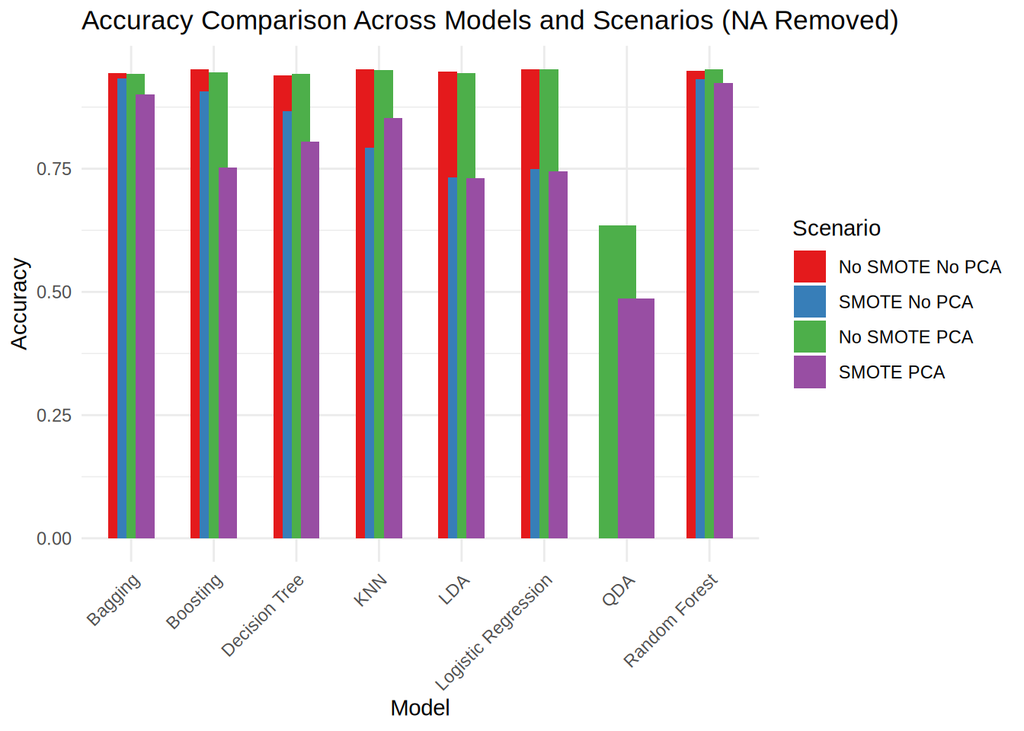

```r
# Accuracy Plot
ggplot(results_df, aes(x = Model, y = Accuracy, fill = Scenario)) +
  geom_bar(stat = "identity", position = position_dodge(width = 0.45)) +
  labs(title = "Accuracy Comparison Across Models and Scenarios (NA Removed)",
       x = "Model",
       y = "Accuracy") +
  theme_minimal() +
  theme(axis.text.x = element_text(angle = 45, hjust = 1)) +
  scale_fill_brewer(palette = "Set1")
```

# Takeaway

With only about 5% strokes in the data, accuracy alone misleads, which is why every model is judged on AUC, sensitivity, and specificity together. The four scenarios exist to price the two big choices: SMOTE rebalances the classes, PCA compresses the features, and the table shows what each costs per model. QDA could not fit in some folds because of rank deficiency, so those rows are out of the comparison. Read the table per metric, because the ranking moves with the metric, which is the honest answer for a rare-event problem like this.